# Lab 5 Exercises

## Exercise 1

Solve the initial value from the start of this lab with the same time step size $\tau=1/300$ but with a smaller space step size of $h=1/500$.

I use the function ‘backwardDifference()’ from the lab:

```r
backwardDifference <- function(u0=function(x) 2*sin(2*pi*x),
                              K=1, L=1, N=30, T=0.1, M=30) {
    # set up space grid
    h <- L/N
    x <- h*(1:(N-1))

    # set up time grid
    tau <- T/M
    t <- tau*(0:M)

    # set up vectors with initial condition
    w <- u0(x)

    # Set up evolution matrix
    gamma <- K*tau/(h^2)
    A <- diag(1+2*gamma, N-1)
    for (k in 1:(N-2)) {
        A[k,k+1] <- -gamma
        A[k+1,k] <- -gamma
    }
    Ainv <- solve(A)

    Temperature <- matrix(0, N-1, M+1)  # Matrix to hold the solution
    Temperature[ , 1] <- w  # Initial value
    # Loop over time steps
    for (j in 1:M) {
        w <- Ainv %*% w
        Temperature[ , j+1] <- w
    }

    # Return a list consisting of time grid, x grid and solution
    return(list(x=x, t=t, w=Temperature))
}
library(plot3Drgl)
```

Because $L=1$ and $h=L/N$, to get the required $h=1/500$ we need to use $N=500$. All other parameters of the function `backwardDifference()` we can leave at their default values.

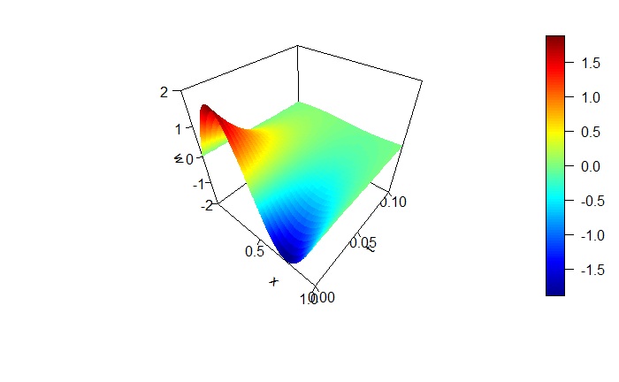

```r
sol <- backwardDifference(N=500)
persp3D(sol$x, sol$t, sol$w,
        xlab="x", ylab="t", zlab="w",
        ticktype="detailed", nticks=4)
```

```r
plotrgl(smooth=TRUE, lighting = TRUE)
```

To get the approximation at $x=0.2, t=0.01$ we determine that this corresponds to $w_{kj}$ with $k=x/h$ and $j=t/\tau$

```r
k <- 0.2/(1/500)
j <- 0.01/(1/300)
k
```

```
[1] 100
```

```r
j
```

```
[1] 3
```

Next we have to remember that we have to shift the time index by one because the first entry is the $t=0$ entry. Thus the answer we are looking for is

```r
sol$w[k,j+1]
```

```
[1] 1.3127
```

## Exercise 2

Use the double sweep method to solve the equation
$$\left(\begin{array}{cccc}
-1 & 2 & 0 & 0\\
2 & -1 & 1 & 0\\
0 & 3 & -1 & 4\\
0 & 0 & 1 & -7
\end{array}\right)
\left(\begin{array}{c} x_{1} \\ x_{2} \\ x_{3} \\ x_{4} \end{array}\right)
=\left(\begin{array}{c} 1 \\ 2 \\ 6 \\ -6 \end{array}\right)$$
We use the function `doublesweep()` from the lab:

```r
doublesweep <- function(A, B, C, F, a, b) {
    # Solves the equation
    # A[i]*v[i-1] - C[i]*v[i] + B[i]*v[i+1] = F[i]
    # for v[i], i = 1,...,N-1, with boundary conditions
    # v[0]=a and v[N]=b

    # Check the lengths of the vectors
    N <- length(C) + 1
    if ((length(B) != N-1) || (length(A) != N-1) || (length(F) != N-1)) {
        stop("The lengths of the vector arguments need to be equal")
    }
    alpha <- rep(0, N)
    beta <- rep(0, N)
    beta[1] <- a

    #sweep up to get alphas and betas
    for (i in 1:(N-1)) {
        alpha[i+1] <- B[i] / (C[i]-alpha[i]*A[i])
        beta[i+1] <- (beta[i]*A[i] - F[i]) / (C[i] - alpha[i]*A[i])
    }

    v <- rep(0, N-1 )
    v[N-1] <- alpha[N]*b + beta[N]

    #sweep down to find v's
    for (i in (N-1):2) {
        v[i-1] <- alpha[i]*v[i] + beta[i]
    }

    return(v)
}
```

We need to set up the vectors $A, B$, and $C$ defining the matrix and the vector $F$. We choose to set $A_1 = B_4 = 0$.

```r
A <- c(0, 2, 3, 1)
B <- c(2, 1, 4, 0)
C <- c(1, 1, 1, 7)
F <- c(1, 2, 6, -6)
```

We can now call the `doublesweep()` function. It does not matter what we choose for the parameters $a$ and $b$ because they are multiplied by zero.

```r
x <- doublesweep(A, B, C, F, 0, 0)
x
```

```
[1] 1 1 1 1
```

This is the solution to the matrix equation.

## Exercise 3

Modify the code of the function `backwardDifference()` so that it uses the double-sweep algorithm rather than matrix inversion. Then test that the new function still gives the same result as the old function, up to rounding errors.

This can be achieved by replacing the line `w <- Ainv %*% w` with `w <- doublesweep(rep(gamma, N-1), rep(gamma, N-1), rep(1 + 2* gamma, N-1), -w, 0, 0)`. I made the choice of signs in order to agree with the conditions on A, B, C given in the notes, but this was not essential. I also remove the code creating the matrix A and inverting it. So I arrive at

```r
backwardDifference <- function(u0=function(x) 2*sin(2*pi*x),
                              K=1, L=1, N=30, T=0.1, M=30) {
    # set up space grid
    h <- L/N
    x <- h*(1:(N-1))

    # set up time grid
    tau <- T/M
    t <- tau*(0:M)

    # set up vectors with initial condition
    w <- u0(x)

    gamma <- K*tau/(h^2)

    Temperature <- matrix(0, N-1, M+1)  # Matrix to hold the solution
    Temperature[ , 1] <- w  # Initial value
    # Loop over time steps
    for (j in 1:M) {
        w <- doublesweep(rep(gamma, N-1), rep(gamma, N-1),
                         rep(1 + 2* gamma, N-1), -w, 0, 0)
        Temperature[ , j+1] <- w
    }

    # Return a list consisting of time grid, x grid and solution
    return(list(x=x, t=t, w=Temperature))
}
```

We test that the modified function still gives the same result:

```r
soln <- backwardDifference(N=500)
max(abs(sol$w-soln$w))
```

```
[1] 3.530509e-14
```

A small difference was to be expected due to different rounding errors.

## Exercise 4

Explore how the error depends on M and N and compare that to your theoretical expectation.

```r
maxError <- function(N, M) {
    # numerical solution
    numSol <- backwardDifference(M=M, N=N)
    # exact solution
    x <- numSol$x
    t <- numSol$t
    xy <- mesh(x, t)
    u <- with(xy, 2*sin(2*pi*x)*exp(-4*pi^2*y))

    return(max(abs(u - numSol$w)))
}
```

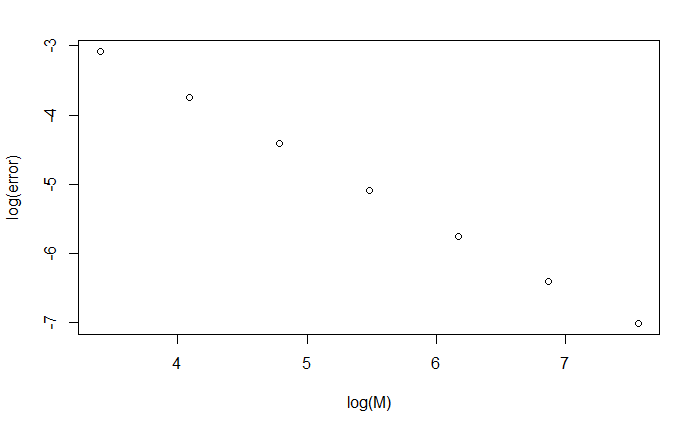

```r
M <- 30*2^(0:6)
N <- 128
error <- sapply(M, function(M) maxError(N, M))
plot(log(M), log(error))
```

We determine the slope of the best fit linear relation

```r
m <- lm(log(error) ~ log(M))
m
```

```
Call:
lm(formula = log(error) ~ log(M))

Coefficients:
(Intercept)       log(M)
     0.1412      -0.9509
```

The slope is roughly $-1$ as expected: the error is $O(\tau)$ and thus $O(M^{-1})$.

Next we investigate the effect of the number of $x$ steps by varying N between 4 and 64:

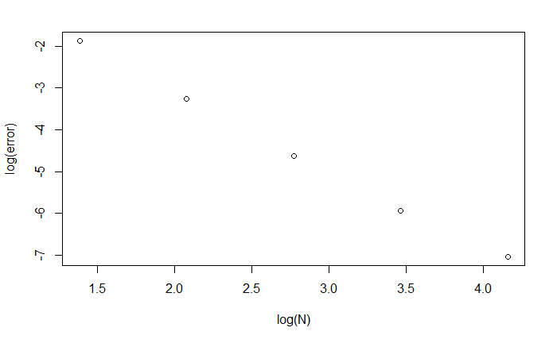

```r
M <- 5000
N <- 4*2^(0:4)
error <- sapply(N, function(N) maxError(N, M))
plot(log(N), log(error))
```

```r
m <- lm(log(error) ~ log(N))
m
```

```
Call:
lm(formula = log(error) ~ log(N))

Coefficients:
(Intercept)       log(N)
     0.6556      -1.8758
```

As excpected, the error goes as $N^{-2}$.